# Data Science Capstone - Milestone Report

Ioannis Labrakis

16 December 2019

# Understanding the Problem

This report aims to interpret the data provided by the Coursera Data Science Capstone Course https://d396qusza40orc.cloudfront.net/dsscapstone/dataset/Coursera-SwiftKey.zip. It will provide the first steps of the final analysis, which contain the loading and exploratory research of the data.

The final project will involve a text predicting model. This model should be able to predict the next probable word wanted by the user.

# Getting and Cleaning the Data

Having the data downloaded, it can be seen that they contain text for different languages, like Russian, Finnish, German and English. In this analysis only the English text will be used, located in the “en_US” folder.

The data were imported into r, after they have been downloaded.

```r
news <- readLines("en_US.news.txt",encoding="UTF-8",skipNul = TRUE)
twitter <- readLines("en_US.twitter.txt",encoding="UTF-8",skipNul = TRUE)
blogs <- readLines("en_US.blogs.txt",encoding="UTF-8",skipNul = TRUE)
```

The data structure were examined and summarized.

```r
library(stringr)
#file size
news_size <- file.info("en_US.news.txt")$size
twitter_size <- file.info("en_US.twitter.txt")$size
blogs_size <- file.info("en_US.blogs.txt")$size
#function to count words
words_count <- function(x){sum(str_count(x,"\\S+"))}
#summary
df <- data.frame(file = c("news","twitter","blogs"),lines = NA, words = NA, size = NA)
text <- list(news = news, twitter = twitter, blogs = blogs)
df$lines <- sapply(text, length)
df$words <- sapply(text, words_count)
df$size <- list(news = news_size, twitter = twitter_size, blogs = blogs_size)
df
```

```
##      file   lines    words      size
## 1    news   77259  2643969 205811889
## 2 twitter 2360148 30373583 167105338
## 3   blogs  899288 37334131 210160014
```

For investigating further the files they needed to be cleaned. Because of their size, a sample of each was taken. The amount of sample taken from each, was 1% of the data.

```r
#sampling
set.seed(101)
news_sample <- sample(news, length(news)*0.01, replace = FALSE)
twitter_sample <- sample(twitter,length(twitter)*0.01, replace = FALSE)
blogs_sample <- sample(blogs,length(blogs)*0.01, replace = FALSE)
#summary of the samples
df_sample <- data.frame(file = c("news_sample","twitter_sample","blogs_sample"),lines = NA, words = NA)
text_sample <- list(news_sample = news_sample, twitter_sample = twitter_sample, blogs_sample = blogs_sample)
df_sample$lines <- sapply(text_sample, length)
df_sample$words <- sapply(text_sample, words_count)
df_sample
```

```
##             file lines  words
## 1    news_sample   772  25663
## 2 twitter_sample 23601 304574
## 3   blogs_sample  8992 373928
```

From the samples taken, a corpus was created and later a token. After that, the data were cleaned by removing special characters, punctuations, numbers, excess whitespace, URLs and change text into lower case. In addition, the profanity of the text needed to be removed. For doing that, a list of 451 profanity words was used which can be found here https://github.com/RobertJGabriel/Google-profanity-words/blob/master/list.txt.

```r
library(quanteda)

data_sample <- c(news_sample,twitter_sample,blogs_sample)
#create corpus
c <- corpus(data_sample)
#profanity words importation
profanityWords <- readLines("./Google-profanity-words-master/list.txt",encoding="UTF-8",skipNul = TRUE)
#Create token and clean the data
token <- tokens(tolower(c), remove_punct = TRUE,remove_numbers = TRUE, remove_symbols = TRUE, remove_hyphens = TRUE, remove_url = TRUE, remove_twitter = TRUE, remove_separators = TRUE)
#remove profanity words
token <- tokens_remove(token, profanityWords, padding = TRUE)
```

# Exploratory Analysis

The next step of the analysis was exploratory. For exploring the data about distinct words, the tokenization was used, breaking sentences and phrases to pairs of words or so called n-grams. N-gram is a contiguous sequence of n items from a given sample of text used in Natural Language Processing (NLP). They are separated into unigrams, bigrams, trigrams until n-grams, containing respectivly a single, two, three until n-word combinations. From the token, 3 document-feature matrices were created, containing a summary table of all the unique tokens in the corpus and the count of times the tokens appeared. The dfms were corresponding to unigrams, bigrams and trigrams of the corpus.

## Unigram

```r
unigram <- dfm(tokens_ngrams(token,n = 1),stem = TRUE, remove = stopwords("english"))
#top 20 unigrams
topfeatures(unigram,20)
```

```
##  just   get   one  like    go  time   day   can  love  good  know thank
##  2602  2492  2489  2473  2188  2062  1931  1891  1848  1587  1555  1554
##  make   now  look   see  work think   new  want
##  1515  1433  1355  1355  1321  1294  1290  1270
```

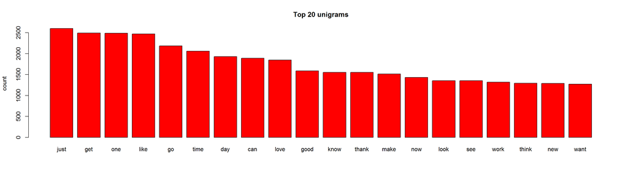

```r
barplot(topfeatures(unigram,20), ylab = "count", main = "Top 20 unigrams", col = "red", cex.names = 1)
```

## Bigram

```r
bigram <- dfm(tokens_ngrams(token,n = 2, concatenator= " "), stem = TRUE, remove = stopwords("english"))
#top 20 bigrams
topfeatures(bigram,20)
```

```
##   of the   in the  for the   to the   on the    to be   at the    go to
##     2565     2482     1388     1366     1220     1178      907      832
##   i have    i was  and the    and i     is a  want to     in a     i am
##      815      789      783      750      744      744      727      726
##   it was   have a with the    it is
##      714      702      694      672
```

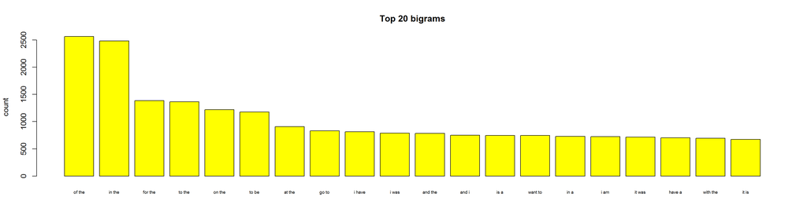

```r
barplot(topfeatures(bigram,20), ylab = "count", main = "Top 20 bigrams", col = "yellow",cex.names = 0.6)
```

## Trigram

```r
trigram <- dfm(tokens_ngrams(token,n = 3, concatenator= " "), stem = TRUE, remove = stopwords("english"))
#top 20 trigrams
topfeatures(trigram,20)
```

```
##   thank for the      one of the       i want to        a lot of
##             266             215             196             171
##         to be a look forward to        go to be       i have to
##             137             133             132             113
##       be abl to   thank you for      as well as      the end of
##             107             104             102             100
##       i need to      out of the     some of the        it was a
##              98              97              95              93
##    i don't know       one of my    in the world        i have a
##              91              91              88              88
```

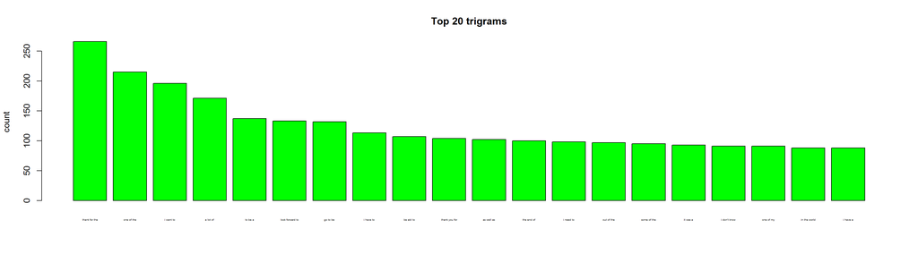

```r
barplot(topfeatures(trigram,20), ylab = "count", main = "Top 20 trigrams", col = "green",cex.names = 0.3)
```

# Future Steps

The next setp of this capstone project will be to create a prediction model. The model will use the input text from the user, tokenize it and match the last words typed with the corpus for predicting the next word.

Afterwards, the prediction model will be integrated into a shiny application.